# F9_06_DISCLOSURE_BOOK_ADDR_STATE

Person possessing the organization’s books and records state · Code report

## Overview

**Description**

**Table**

`F9-P06-T00-GOVERNANCE` (one)

**Location code**

`F990-PC-PART-06-SECTION-C-LINE-20`, `F990-EZ-PART-05-LINE-42A`

**Family**

`F990-PC-PART-06-SECTION-C-LINE-20` · siblings: F9_06_DISCLOSURE_BOOK_ADDR_CITY, F9_06_DISCLOSURE_BOOK_ADDR_CNTR, F9_06_DISCLOSURE_BOOK_ADDR_L1, F9_06_DISCLOSURE_BOOK_ADDR_L2, F9_06_DISCLOSURE_BOOK_ADDR_ZIP, F9_06_DISCLOSURE_BOOK_NAME_L1

**Data type**

text (xsd: CountryType, TextType, StateType, )

**Scope**

PZ

**Status**

unreviewed

15

xpaths mapped (13 observed)

5,983,424

filings with a value

2009–2024

tax years observed

3

open flags (1 errors)

## Flags

| Severity | Flag | Xpath | Detail |
| --- | --- | --- | --- |
| ⚠ error | `COLLISION` | IRS990/BooksInCareOfDetail/ForeignAddress/CountryCd | 4093 filings contain 2+ of its xpaths; most common set: /Return/ReturnData/IRS990/BooksInCareOfDetail/ForeignAddress/CountryCd ; /Return/ReturnData/IRS990/BooksInCareOfDetail/ForeignAddress/ProvinceOr… |
| ⓘ info | `UNOBSERVED` | IRS990/Form990PartVI/TheBooksAreInCareOf/AddressForeign/ProvinceOrState | never observed in TY2009-2024 filings |
| ⓘ info | `UNOBSERVED` | IRS990/Form990PartVI/TheBooksAreInCareOf/AddressUS/State | never observed in TY2009-2024 filings |

## Xpaths

All mapped xpaths (under /Return/ReturnData or /Return/ReturnHeader), oldest first. Charts label each series by its xpath.

| Xpath | Form | Chart label | First year | Last year | Versions | Filings | Repeats in |
| --- | --- | --- | --- | --- | --- | --- | --- |
| IRS990/TheBooksAreInCareOf/AddressUS/State | 990 | same | 2009 | 2012 | 19 | 494,711 | 0.0% |
| IRS990EZ/TheBooksAreInCareOf/AddressUS/State | 990-EZ | same | 2009 | 2012 | 18 | 254,277 | 0.0% |
| IRS990/TheBooksAreInCareOf/AddressForeign/ProvinceOrState | 990 | same | 2009 | 2012 | 15 | 358 | 0.0% |
| IRS990EZ/TheBooksAreInCareOf/AddressForeign/ProvinceOrState | 990-EZ | same | 2009 | 2012 | 11 | 109 | 0.0% |
| IRS990/BooksInCareOfDetail/USAddress/State | 990 | same | 2013 | 2013 | 3 | 198,513 | 0.0% |
| IRS990EZ/BooksInCareOfDetail/USAddress/State | 990-EZ | same | 2013 | 2013 | 3 | 104,251 | 0.0% |
| IRS990/BooksInCareOfDetail/ForeignAddress/ProvinceOrState | 990 | same | 2013 | 2013 | 3 | 164 | 0.0% |
| IRS990/BooksInCareOfDetail/ForeignAddress/CountryCd | 990 | Other | 2014 | 2024 | 34 | 7,059 | 0.0% |
| IRS990/BooksInCareOfDetail/ForeignAddress/ProvinceOrStateNm | 990 | Other | 2014 | 2024 | 34 | 4,093 | 0.0% |
| IRS990/BooksInCareOfDetail/USAddress/StateAbbreviationCd | 990 | Other | 2014 | 2024 | 35 | 3,143,699 | 0.0% |
| IRS990/Form990PartVI/TheBooksAreInCareOf/AddressForeign/ProvinceOrState | 990 | Other |  |  |  | 0 |  |
| IRS990/Form990PartVI/TheBooksAreInCareOf/AddressUS/State | 990 | Other |  |  |  | 0 |  |
| IRS990EZ/BooksInCareOfDetail/ForeignAddress/ProvinceOrState | 990-EZ | Other | 2013 | 2013 | 3 | 54 | 0.0% |
| IRS990EZ/BooksInCareOfDetail/ForeignAddress/ProvinceOrStateNm | 990-EZ | Other | 2014 | 2024 | 33 | 1,426 | 0.0% |
| IRS990EZ/BooksInCareOfDetail/USAddress/StateAbbreviationCd | 990-EZ | Other | 2014 | 2024 | 35 | 1,774,710 | 0.0% |

## Coverage

[figure not shown]

**Table view**

Table view: filings by tax year and series

| Tax year | IRS990/TheBooksAreInCareOf/AddressUS/State | IRS990EZ/TheBooksAreInCareOf/AddressUS/State | IRS990/TheBooksAreInCareOf/AddressForeign/ProvinceOrState | IRS990EZ/TheBooksAreInCareOf/AddressForeign/ProvinceOrState | IRS990/BooksInCareOfDetail/USAddress/State | IRS990EZ/BooksInCareOfDetail/USAddress/State | IRS990/BooksInCareOfDetail/ForeignAddress/ProvinceOrState | Other |
| --- | --- | --- | --- | --- | --- | --- | --- | --- |
| 2009 | 33,256 | 15,455 | 29 | 4 | 0 | 0 | 0 | 0 |
| 2010 | 122,818 | 63,236 | 89 | 30 | 0 | 0 | 0 | 0 |
| 2011 | 159,241 | 81,947 | 108 | 36 | 0 | 0 | 0 | 0 |
| 2012 | 179,396 | 93,639 | 132 | 39 | 0 | 0 | 0 | 0 |
| 2013 | 0 | 0 | 0 | 0 | 198,513 | 104,251 | 164 | 54 |
| 2014 | 0 | 0 | 0 | 0 | 0 | 0 | 0 | 335,145 |
| 2015 | 0 | 0 | 0 | 0 | 0 | 0 | 0 | 358,542 |
| 2016 | 0 | 0 | 0 | 0 | 0 | 0 | 0 | 374,542 |
| 2017 | 0 | 0 | 0 | 0 | 0 | 0 | 0 | 400,948 |
| 2018 | 0 | 0 | 0 | 0 | 0 | 0 | 0 | 421,030 |
| 2019 | 0 | 0 | 0 | 0 | 0 | 0 | 0 | 436,580 |
| 2020 | 0 | 0 | 0 | 0 | 0 | 0 | 0 | 490,614 |
| 2021 | 0 | 0 | 0 | 0 | 0 | 0 | 0 | 539,658 |
| 2022 | 0 | 0 | 0 | 0 | 0 | 0 | 0 | 555,672 |
| 2023 | 0 | 0 | 0 | 0 | 0 | 0 | 0 | 561,672 |
| 2024 | 0 | 0 | 0 | 0 | 0 | 0 | 0 | 456,584 |

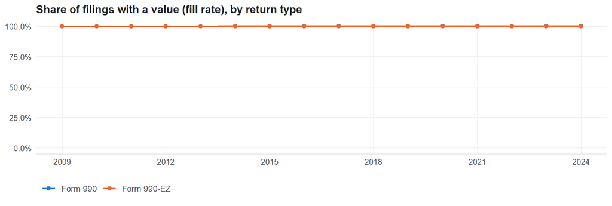

**Table view**

Table view: fill rate

| Tax year | Return type | Filings | All filings | Fill rate |
| --- | --- | --- | --- | --- |
| 2009 | Form 990 | 33,285 | 33,311 | 99.92% |
| 2009 | Form 990-EZ | 15,459 | 15,470 | 99.93% |
| 2010 | Form 990 | 122,907 | 123,025 | 99.90% |
| 2010 | Form 990-EZ | 63,266 | 63,326 | 99.91% |
| 2011 | Form 990 | 159,349 | 159,504 | 99.90% |
| 2011 | Form 990-EZ | 81,983 | 82,048 | 99.92% |
| 2012 | Form 990 | 179,528 | 179,688 | 99.91% |
| 2012 | Form 990-EZ | 93,678 | 93,750 | 99.92% |
| 2013 | Form 990 | 198,677 | 198,855 | 99.91% |
| 2013 | Form 990-EZ | 104,305 | 104,375 | 99.93% |
| 2014 | Form 990 | 218,802 | 218,619 | 100.08% |
| 2014 | Form 990-EZ | 116,343 | 116,417 | 99.94% |
| 2015 | Form 990 | 233,714 | 233,519 | 100.08% |
| 2015 | Form 990-EZ | 124,828 | 124,894 | 99.95% |
| 2016 | Form 990 | 244,121 | 243,903 | 100.09% |
| 2016 | Form 990-EZ | 130,421 | 130,484 | 99.95% |
| 2017 | Form 990 | 261,863 | 261,612 | 100.10% |
| 2017 | Form 990-EZ | 139,084 | 139,144 | 99.96% |
| 2018 | Form 990 | 271,715 | 271,442 | 100.10% |
| 2018 | Form 990-EZ | 149,315 | 149,384 | 99.95% |
| 2019 | Form 990 | 284,022 | 283,694 | 100.12% |
| 2019 | Form 990-EZ | 152,557 | 152,622 | 99.96% |
| 2020 | Form 990 | 320,821 | 320,342 | 100.15% |
| 2020 | Form 990-EZ | 169,791 | 169,864 | 99.96% |
| 2021 | Form 990 | 336,998 | 336,480 | 100.15% |
| 2021 | Form 990-EZ | 202,647 | 202,724 | 99.96% |
| 2022 | Form 990 | 349,615 | 349,055 | 100.16% |
| 2022 | Form 990-EZ | 206,045 | 206,130 | 99.96% |
| 2023 | Form 990 | 355,367 | 354,768 | 100.17% |
| 2023 | Form 990-EZ | 206,296 | 206,379 | 99.96% |
| 2024 | Form 990 | 277,787 | 277,298 | 100.18% |
| 2024 | Form 990-EZ | 178,792 | 178,867 | 99.96% |

## Values

[output not shown]

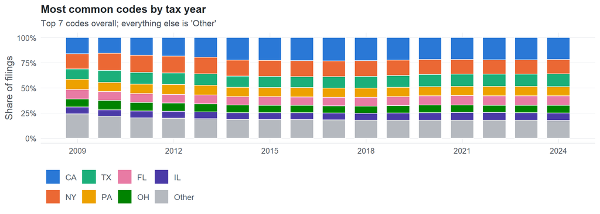

**Table view**

Table view: filings by code and tax year

| tax_year | CA | NY | TX | PA | FL | OH | IL | Other |
| --- | --- | --- | --- | --- | --- | --- | --- | --- |
| 2009 | 4,107 | 3,856 | 2,553 | 2,633 | 2,402 | 2,004 | 1,740 | 6,142 |
| 2010 | 14,651 | 16,123 | 11,211 | 8,527 | 8,335 | 8,579 | 5,974 | 20,549 |
| 2011 | 21,513 | 20,896 | 14,247 | 11,824 | 10,746 | 10,447 | 8,179 | 24,880 |
| 2012 | 25,627 | 23,431 | 15,979 | 13,712 | 12,177 | 11,483 | 9,526 | 27,665 |
| 2013 | 30,643 | 25,523 | 17,766 | 15,161 | 13,493 | 12,371 | 10,670 | 30,165 |
| 2014 | 39,465 | 27,627 | 19,585 | 16,372 | 14,749 | 13,146 | 11,849 | 32,723 |
| 2015 | 42,811 | 29,635 | 20,895 | 17,385 | 15,913 | 13,878 | 12,830 | 34,581 |
| 2016 | 45,136 | 30,883 | 21,500 | 18,235 | 16,310 | 14,445 | 13,368 | 35,973 |
| 2017 | 48,653 | 33,373 | 23,724 | 19,142 | 17,923 | 15,095 | 14,225 | 38,111 |
| 2018 | 50,364 | 34,960 | 25,467 | 20,017 | 19,316 | 15,778 | 14,977 | 39,625 |
| 2019 | 51,075 | 35,075 | 26,719 | 21,105 | 20,300 | 16,479 | 16,224 | 41,039 |
| 2020 | 55,710 | 37,593 | 30,392 | 23,737 | 23,118 | 18,871 | 18,935 | 45,567 |
| 2021 | 60,915 | 40,291 | 33,655 | 25,874 | 25,871 | 20,624 | 21,071 | 50,057 |
| 2022 | 62,992 | 41,260 | 35,225 | 26,444 | 26,803 | 21,112 | 21,586 | 51,332 |
| 2023 | 63,570 | 41,180 | 35,790 | 26,723 | 27,325 | 21,390 | 21,479 | 51,412 |
| 2024 | 50,873 | 33,358 | 29,841 | 21,281 | 22,265 | 17,641 | 17,368 | 41,334 |

Code frequencies (all xpaths, all years)

| Code | Filings | Share |
| --- | --- | --- |
| CA | 668,105 | 21.6% |
| NY | 475,064 | 15.3% |
| TX | 364,549 | 11.8% |
| PA | 288,172 | 9.3% |
| FL | 277,046 | 8.9% |
| OH | 233,343 | 7.5% |
| IL | 220,001 | 7.1% |
| MA | 195,107 | 6.3% |
| MI | 127,217 | 4.1% |
| VA | 104,070 | 3.4% |
| NJ | 72,285 | 2.3% |
| GA | 30,040 | 1.0% |
| NC | 27,853 | 0.9% |
| MN | 8,130 | 0.3% |
| UK | 1,038 | 0.0% |
| RQ | 713 | 0.0% |
| ONTARIO | 606 | 0.0% |
| IS | 495 | 0.0% |
| WA | 489 | 0.0% |
| Ontario | 465 | 0.0% |
| PR | 396 | 0.0% |
| BC | 307 | 0.0% |
| PUERTO RICO | 204 | 0.0% |
| Surrey | 161 | 0.0% |
| IT | 157 | 0.0% |
| Puerto Rico | 137 | 0.0% |
| FR | 136 | 0.0% |
| ON | 107 | 0.0% |
| SZ | 104 | 0.0% |
| KE | 100 | 0.0% |

First rows shown.

## Examples

| Tax year | Return | Xpath | Organization | Value | Source |
| --- | --- | --- | --- | --- | --- |
| 2024 | 990 | IRS990/BooksInCareOfDetail/ForeignAddress/CountryCd | Bishop’s College School Foundation | CA | [XML](https://gt990datalake-rawdata.s3.amazonaws.com/EfileData/XmlFiles/202523189349308497_public.xml) |
| 2024 | 990 | IRS990/BooksInCareOfDetail/ForeignAddress/ProvinceOrStateNm | Under the Same Sun Foundation (USA) | BC | [XML](https://gt990datalake-rawdata.s3.amazonaws.com/EfileData/XmlFiles/202503529349301610_public.xml) |
| 2024 | 990 | IRS990/BooksInCareOfDetail/USAddress/StateAbbreviationCd | CHRISTIAN SHANE FONVILLE YOUTH | TX | [XML](https://gt990datalake-rawdata.s3.amazonaws.com/EfileData/XmlFiles/202511059349301411_public.xml) |
| 2024 | 990EZ | IRS990EZ/BooksInCareOfDetail/ForeignAddress/ProvinceOrStateNm | INTERNATIONAL XENOTRANSPLANTATION ASSOCIATION | QC | [XML](https://gt990datalake-rawdata.s3.amazonaws.com/EfileData/XmlFiles/202533169349203183_public.xml) |
| 2024 | 990EZ | IRS990EZ/BooksInCareOfDetail/USAddress/StateAbbreviationCd | SAINT CLAIR HOUSE INC | OH | [XML](https://gt990datalake-rawdata.s3.amazonaws.com/EfileData/XmlFiles/202521329349201597_public.xml) |
| 2023 | 990 | IRS990/BooksInCareOfDetail/ForeignAddress/CountryCd | Friends of the British Film Institute | UK | [XML](https://gt990datalake-rawdata.s3.amazonaws.com/EfileData/XmlFiles/202421219349302457_public.xml) |
| 2023 | 990 | IRS990/BooksInCareOfDetail/ForeignAddress/ProvinceOrStateNm | CENTROS SOR ISOLINA FERRE INC | PUERTO RICO | [XML](https://gt990datalake-rawdata.s3.amazonaws.com/EfileData/XmlFiles/202500229349300640_public.xml) |
| 2023 | 990 | IRS990/BooksInCareOfDetail/USAddress/StateAbbreviationCd | ZEPF CENTER | OH | [XML](https://gt990datalake-rawdata.s3.amazonaws.com/EfileData/XmlFiles/202423399349300887_public.xml) |
| 2023 | 990EZ | IRS990EZ/BooksInCareOfDetail/ForeignAddress/ProvinceOrStateNm | WORLD LIVINGWATER EDUCATION | BAJA CALIFORNIA | [XML](https://gt990datalake-rawdata.s3.amazonaws.com/EfileData/XmlFiles/202440949349200834_public.xml) |
| 2023 | 990EZ | IRS990EZ/BooksInCareOfDetail/USAddress/StateAbbreviationCd | The Canaan Protective Fire Company | NY | [XML](https://gt990datalake-rawdata.s3.amazonaws.com/EfileData/XmlFiles/202412069349200736_public.xml) |
| 2022 | 990 | IRS990/BooksInCareOfDetail/ForeignAddress/CountryCd | KEVIN SPACEY FOUNDATION AMERICA | UK | [XML](https://gt990datalake-rawdata.s3.amazonaws.com/EfileData/XmlFiles/202333129349300043_public.xml) |
| 2022 | 990 | IRS990/BooksInCareOfDetail/ForeignAddress/ProvinceOrStateNm | KEVIN SPACEY FOUNDATION AMERICA | Surrey | [XML](https://gt990datalake-rawdata.s3.amazonaws.com/EfileData/XmlFiles/202333129349300043_public.xml) |

## Reviewer checklist

- The definition matches the form line and instructions for every xpath’s schema years.
- Every xpath pooled here measures the same thing on the 990 and 990-EZ (close enough for analysis).
- The coverage chart has no unexplained gaps or jumps between tax years.
- Each open flag is fixed, or accepted with a note in validation_log.csv.
- Every code is valid for the list the form uses (state, country, valuation method, …).
- The code list and its meaning did not change across schema versions.
- Codes are stored as text, so values like leading zeros are preserved.

Record the review as a row in `inst/extdata/src/validation_log.csv` (variable_name, reviewer, date, status, note). Evidence built 2026-09-23 17:09:04 MST from the ef2 DuckDB builds (tax years 2009–2024).